# Analisis Pendapatan dan Popularitas Kategori Film pada Database Sakila

Nurul Hasanah M0725029 C

2026-05-25

# Pendahuluan

Database Sakila merupakan database simulasi sistem rental film yang dikembangkan oleh MySQL. Database ini berisi data pelanggan, transaksi rental, pembayaran, kategori film, inventory, dan berbagai informasi lain yang berkaitan dengan sistem rental film.

Pada laporan ini dilakukan analisis terhadap kategori film berdasarkan jumlah rental dan total pendapatan yang diperoleh perusahaan rental film.

Tujuan dari analisis ini yaitu:

1. Mengetahui kategori film dengan jumlah rental tertinggi.
2. Mengetahui kategori film dengan total pendapatan terbesar.
3. Menganalisis hubungan antara jumlah rental dan pendapatan.
4. Memberikan insight bisnis berdasarkan data yang dianalisis.

Analisis ini penting karena perusahaan dapat memahami preferensi pelanggan serta menentukan strategi bisnis yang lebih efektif berbasis data.

# Insight yang Diambil

Insight utama yang diambil dalam analisis ini adalah hubungan antara popularitas kategori film dengan pendapatan yang diperoleh perusahaan rental film.

Insight ini dipilih karena perusahaan rental film perlu memahami kategori film yang paling diminati pelanggan agar dapat:

- Meningkatkan strategi pemasaran,
- Mengoptimalkan inventory film,
- Meningkatkan profit perusahaan,
- Serta memahami pola perilaku pelanggan berdasarkan data transaksi rental.

Melalui visualisasi dan analisis statistik, diharapkan perusahaan dapat memperoleh informasi yang berguna dalam pengambilan keputusan bisnis berbasis data.

# Import Library

```r
library(DBI)
library(RMySQL)
library(ggplot2)
library(knitr)
library(scales)
```

# Koneksi Database

```r
sakilaction = dbConnect(
  RMySQL::MySQL(),
  dbname = "sakila",
  host = "127.0.0.1",
  port = 3306,
  user = "root",
  password = "admin123"
)
```

# Pengambilan Data

Data diambil menggunakan query SQL berikut.

```r
query = "SELECT
    c.name AS category,
    COUNT(r.rental_id) AS total_rental,
    SUM(p.amount) AS total_revenue,
    AVG(f.length) AS avg_duration

FROM category c
JOIN film_category fc
    ON c.category_id = fc.category_id
JOIN film f
    ON fc.film_id = f.film_id
JOIN inventory i
    ON f.film_id = i.film_id
JOIN rental r
    ON i.inventory_id = r.inventory_id
JOIN payment p
    ON r.rental_id = p.rental_id
GROUP BY c.name
ORDER BY total_revenue DESC"

film_data = dbGetQuery(sakilaction, query)
kable(film_data)
```

| category | total_rental | total_revenue | avg_duration |
| --- | --- | --- | --- |
| Sports | 1179 | 5314.21 | 128.7498 |
| Sci-Fi | 1101 | 4756.98 | 105.5649 |
| Animation | 1166 | 4656.30 | 108.7787 |
| Drama | 1060 | 4587.39 | 122.6047 |
| Comedy | 941 | 4383.58 | 111.7109 |
| Action | 1112 | 4375.85 | 108.7455 |
| New | 940 | 4351.62 | 109.0500 |
| Games | 969 | 4281.33 | 128.1538 |
| Foreign | 1033 | 4270.67 | 123.1249 |
| Family | 1096 | 4226.07 | 111.3294 |
| Documentary | 1050 | 4217.52 | 110.9714 |
| Horror | 846 | 3722.54 | 113.3227 |
| Children | 945 | 3655.55 | 111.4423 |
| Classics | 939 | 3639.59 | 113.0618 |
| Travel | 837 | 3549.64 | 117.0072 |
| Music | 830 | 3417.72 | 115.7036 |

# Deskripsi Dataset

Dataset yang digunakan berasal dari database Sakila.

Variabel yang digunakan pada analisis ini meliputi:

| Variabel | Keterangan |
| --- | --- |
| category | Nama kategori film |
| total_rental | Total jumlah rental |
| total_revenue | Total pendapatan |
| avg_duration | Rata-rata durasi film |

# Data Preparation

Tahap data preparation dilakukan untuk memastikan data siap digunakan dalam proses analisis dan visualisasi.

```r
str(film_data)
```

```
## 'data.frame':    16 obs. of  4 variables:
##  $ category     : chr  "Sports" "Sci-Fi" "Animation" "Drama" ...
##  $ total_rental : num  1179 1101 1166 1060 941 ...
##  $ total_revenue: num  5314 4757 4656 4587 4384 ...
##  $ avg_duration : num  129 106 109 123 112 ...
```

```r
summary(film_data)
```

```
##    category          total_rental    total_revenue   avg_duration
##  Length:16          Min.   : 830.0   Min.   :3418   Min.   :105.6
##  Class :character   1st Qu.: 939.8   1st Qu.:3706   1st Qu.:110.5
##  Mode  :character   Median :1001.0   Median :4276   Median :112.4
##                     Mean   :1002.8   Mean   :4213   Mean   :115.0
##                     3rd Qu.:1097.2   3rd Qu.:4435   3rd Qu.:118.4
##                     Max.   :1179.0   Max.   :5314   Max.   :128.7
```

```r
sum(is.na(film_data))
```

```
## [1] 0
```

Berdasarkan hasil pengecekan, data tidak memiliki missing value sehingga data dapat langsung digunakan untuk proses analisis.

# 1. Total Pendapatan per Kategori Film

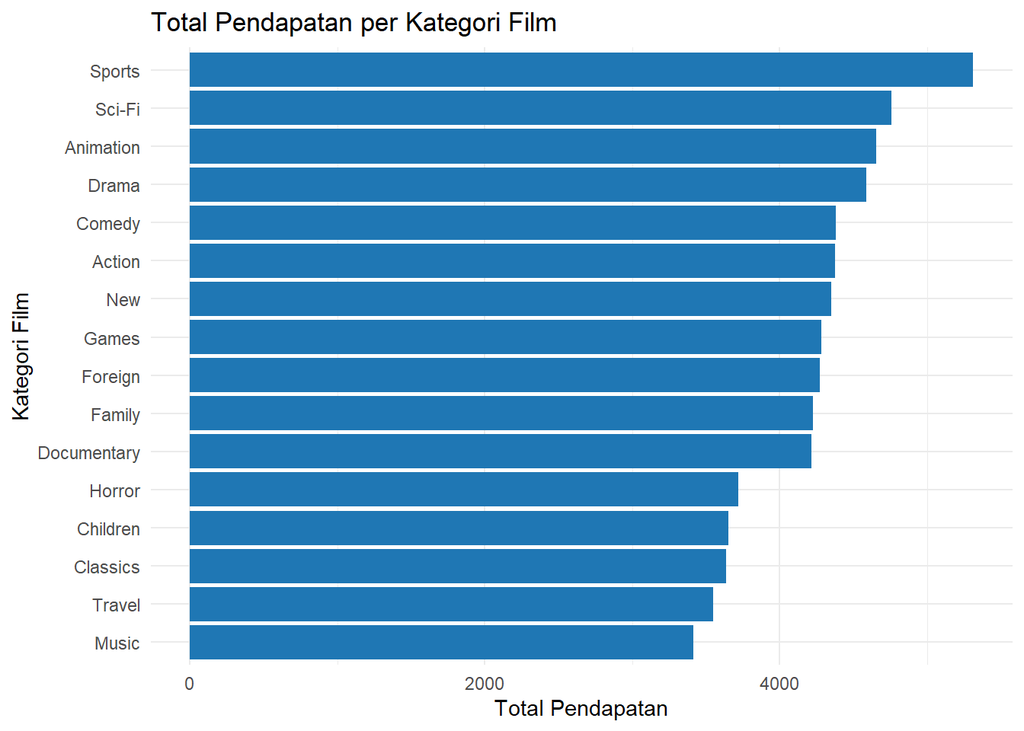

```r
ggplot(
  film_data,
  aes(
    x = reorder(category, total_revenue),
    y = total_revenue
  )
) + geom_bar(
  stat = "identity",
  fill = "#1f77b4"
) + coord_flip() + labs(
  title = "Total Pendapatan per Kategori Film",
  x = "Kategori Film",
  y = "Total Pendapatan"
) + theme_minimal()
```

# Interpretasi Visualisasi Total Pendapatan per Kategori Film

Visualisasi di atas menunjukkan total pendapatan yang diperoleh dari setiap kategori film.

Terlihat bahwa beberapa kategori film memiliki pendapatan yang jauh lebih tinggi dibanding kategori lainnya. Hal ini menunjukkan bahwa pelanggan memiliki preferensi yang lebih besar terhadap kategori tertentu.

Kategori dengan revenue tertinggi mengindikasikan bahwa kategori tersebut memiliki tingkat permintaan yang tinggi di pasar rental film. Tingginya pendapatan dapat dipengaruhi oleh:

1. Popularitas genre film.
2. Banyaknya inventory yang tersedia.
3. Tingginya frekuensi rental pelanggan.
4. Ketertarikan pelanggan terhadap jenis film tertentu.

Sebaliknya, kategori dengan pendapatan rendah menunjukkan bahwa minat pelanggan terhadap kategori tersebut relatif lebih kecil.

Berdasarkan insight ini, perusahaan rental dapat:

- Menambah koleksi film populer,
- Mengoptimalkan inventory,
- Membuat strategi promosi berdasarkan kategori,
- Serta meningkatkan efisiensi bisnis.

# 2. Jumlah Rental per Kategori Film

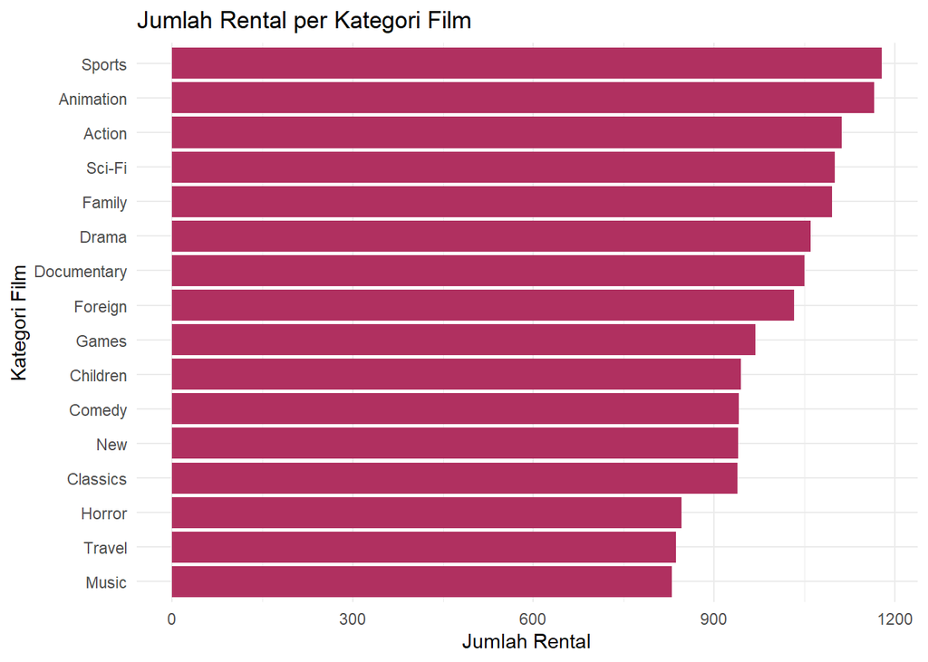

```r
ggplot(
  film_data,
  aes(
    x = reorder(category, total_rental),
    y = total_rental
  )
) + geom_bar(
  stat = "identity",
  fill = "maroon"
) + coord_flip() + labs(
  title = "Jumlah Rental per Kategori Film",
  x = "Kategori Film",
  y = "Jumlah Rental"
) + theme_minimal()
```

# Interpretasi Visualisasi Jumlah Rental per Kategori Film

Visualisasi di atas menunjukkan jumlah rental untuk masing-masing kategori film.

Kategori dengan jumlah rental tinggi menunjukkan bahwa pelanggan lebih sering memilih film dari kategori tersebut dibanding kategori lain.

Tingginya jumlah rental dapat dipengaruhi oleh:

- Preferensi pelanggan,
- Tren hiburan,
- Kualitas film,
- Jumlah film yang tersedia,
- Serta tingkat popularitas genre.

Data ini sangat penting karena perusahaan dapat mengetahui kategori film yang paling diminati pelanggan sehingga dapat digunakan sebagai dasar pengambilan keputusan bisnis.

# 3. Hubungan Jumlah Rental dan Total Revenue

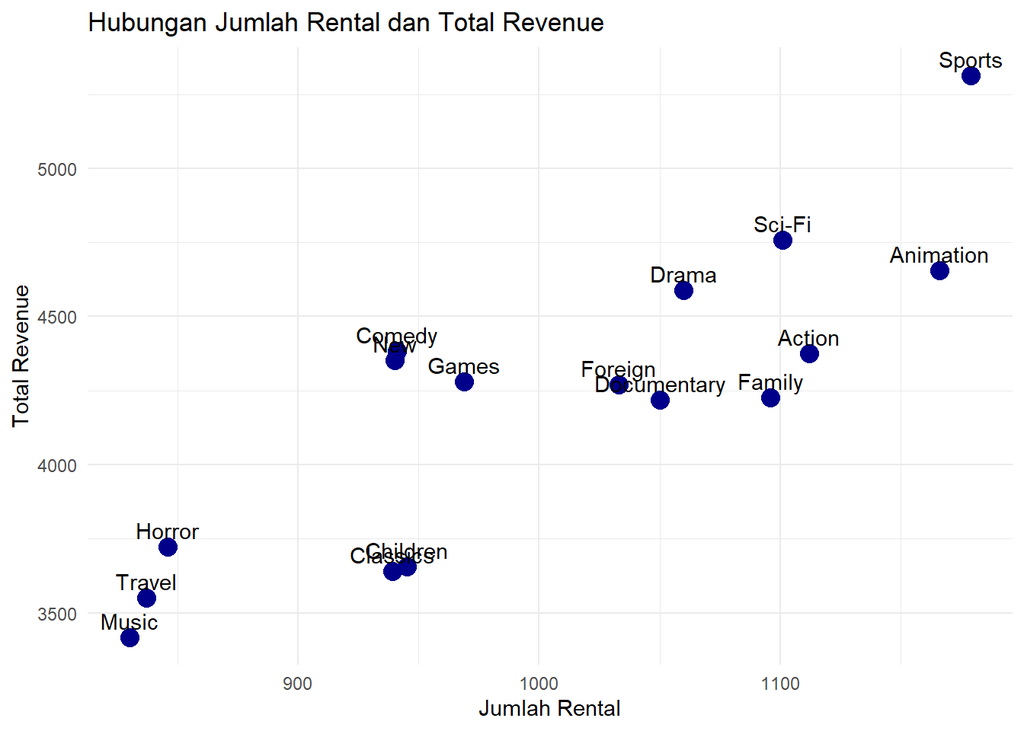

```r
ggplot(
  film_data,
  aes(
    x = total_rental,
    y = total_revenue,
    label = category
  )
) + geom_point(
  size = 4,
  color = "darkblue"
) + geom_text(
  vjust = -0.5
) + labs(
  title = "Hubungan Jumlah Rental dan Total Revenue",
  x = "Jumlah Rental",
  y = "Total Revenue"
) + theme_minimal()
```

# Interpretasi Visualisasi Hubungan Jumlah Rental dan Total Revenue

Scatter plot menunjukkan hubungan antara jumlah rental dan total revenue.

Titik-titik pada grafik cenderung membentuk pola meningkat dari kiri bawah menuju kanan atas. Hal ini menunjukkan adanya hubungan positif antara jumlah rental dan total pendapatan.

Dengan kata lain, semakin tinggi jumlah rental pada suatu kategori film, maka semakin besar pula pendapatan yang diperoleh perusahaan.

# Statistik Deskriptif

```r
summary(film_data)
```

```
##    category          total_rental    total_revenue   avg_duration
##  Length:16          Min.   : 830.0   Min.   :3418   Min.   :105.6
##  Class :character   1st Qu.: 939.8   1st Qu.:3706   1st Qu.:110.5
##  Mode  :character   Median :1001.0   Median :4276   Median :112.4
##                     Mean   :1002.8   Mean   :4213   Mean   :115.0
##                     3rd Qu.:1097.2   3rd Qu.:4435   3rd Qu.:118.4
##                     Max.   :1179.0   Max.   :5314   Max.   :128.7
```

# Analisis Korelasi

```r
correlation = cor(
  film_data$total_rental,
  film_data$total_revenue
)

correlation
```

```
## [1] 0.8486797
```

# Interpretasi Analisis Korelasi

Koefisien korelasi digunakan untuk mengetahui kekuatan hubungan antara jumlah rental dan total pendapatan.

Jika nilai korelasi mendekati 1, maka hubungan antara kedua variabel bersifat positif kuat.

Artinya, peningkatan jumlah rental cenderung diikuti dengan peningkatan pendapatan perusahaan.

# Persamaan Matematis Menggunakan LaTeX

Rata-rata pendapatan dapat dihitung menggunakan persamaan berikut.

$$\bar{x} = \frac{\sum x}{n}$$

Keterangan:

- $\bar{x}$ = rata-rata pendapatan
- $\sum x$ = total seluruh pendapatan
- $n$ = jumlah data

Persamaan korelasi Pearson:

$$r =
\frac{
n\sum xy - (\sum x)(\sum y)
}
{
\sqrt{
[n\sum x^2 - (\sum x)^2]
[n\sum y^2 - (\sum y)^2]
}
}$$

Persamaan regresi linear:

$$y = a + bx$$

Keterangan:

- $y$ = variabel dependen
- $x$ = variabel independen
- $a$ = konstanta
- $b$ = koefisien regresi

# Analisis Regresi Linear

```r
model = lm(
  total_revenue ~ total_rental,
  data = film_data
)

summary(model)
```

```
##
## Call:
## lm(formula = total_revenue ~ total_rental, data = film_data)
##
## Residuals:
##     Min      1Q  Median      3Q     Max
## -342.09 -197.21  -44.65  176.58  429.85
##
## Coefficients:
##              Estimate Std. Error t value Pr(>|t|)
## (Intercept)  392.8032   640.0757   0.614    0.549
## total_rental   3.8096     0.6345   6.004 3.23e-05 ***
## ---
## Signif. codes:  0 '***' 0.001 '**' 0.01 '*' 0.05 '.' 0.1 ' ' 1
##
## Residual standard error: 278.5 on 14 degrees of freedom
## Multiple R-squared:  0.7203, Adjusted R-squared:  0.7003
## F-statistic: 36.05 on 1 and 14 DF,  p-value: 3.233e-05
```

# Interpretasi Regresi Linear

Analisis regresi linear digunakan untuk mengetahui pengaruh jumlah rental terhadap total revenue.

Jika nilai koefisien regresi bernilai positif, maka peningkatan jumlah rental akan meningkatkan total pendapatan perusahaan.

Regresi linear juga membantu perusahaan dalam melakukan prediksi revenue berdasarkan jumlah rental di masa mendatang.

# Kesimpulan

Berdasarkan hasil visualisasi dan analisis data, dapat disimpulkan bahwa kategori film tertentu memiliki performa yang lebih baik dibanding kategori lainnya dalam menghasilkan revenue.

Jumlah rental terbukti memiliki hubungan positif terhadap total pendapatan perusahaan. Semakin tinggi jumlah rental suatu kategori, maka semakin besar pula pendapatan yang diperoleh.

Melalui analisis data menggunakan database Sakila, perusahaan rental film dapat memahami pola perilaku pelanggan serta menentukan strategi bisnis yang lebih efektif dan berbasis data.

# Menutup Koneksi Database

```r
dbDisconnect(sakilaction)
```

```
## [1] TRUE
```